# Martensite Starting Temperature-Data Visualization & Data Exploration

Author

Hooman Sabarou-Cross_Validation Group_Fall 2024

### Introduction to the Dataset (Martensite Starting Temperature)

This dataset contains the chemical compositions of various steels along with their Martensite starting temperatures (Ms), aiming to develop a model that predicts Ms based on steel chemistry.

Martensite is a phase where steel becomes extremely strong and can withstand high stresses, making it essential for industries like automotive to enhance crash safety. Ms is the critical temperature where steel’s internal structure changes into Martensite, and it varies with chemical composition. Currently, determining Ms requires lengthy tests using Thermogravimetry (TGA), which are prone to errors and often need repeating. A predictive model would save significant time and effort by eliminating the need for these tests.

### The head of the dataset

```
     C   Mn   Si   Cr   Ni   Mo    V Co   Al W   Cu Nb Ti B     N     Ms
1 0.19 1.25 0.23 0.07 0.66 0.54 0.00  0 0.00 0 0.00  0  0 0 0.000 645.00
2 1.00 0.45 0.00 1.52 3.33 0.00 0.00  0 0.00 0 0.00  0  0 0 0.000 359.00
3 0.26 0.58 0.49 1.65 0.18 0.84 0.38  0 0.00 0 0.07  0  0 0 0.000 653.00
4 0.06 1.96 0.32 0.00 0.00 0.18 0.22  0 0.02 0 0.00  0  0 0 0.005 721.00
5 1.20 1.88 0.00 0.00 0.00 0.00 0.00  0 0.00 0 0.00  0  0 0 0.000 323.00
6 0.38 0.69 0.20 0.95 1.58 0.26 0.00  0 0.00 0 0.00  0  0 0 0.000 589.75
```

**C, Mn, Si, Cr, and etc. are referred to chemical elements based on the Periodic Table. They are Carbon, Manganese, Silicon, Chromium, and so on.**

### Checking for missing values

```
[1] 0
```

**There are no missing values.**

### Checking the Structure of the Dataset

```
'data.frame':   1543 obs. of  16 variables:
 $ C : num  0.19 1 0.26 0.06 1.2 0.38 0.43 0.004 0 2 ...
 $ Mn: num  1.25 0.45 0.58 1.96 1.88 0.69 0.83 0.03 0 0.65 ...
 $ Si: num  0.23 0 0.49 0.32 0 0.2 1.55 0.075 0 0.3 ...
 $ Cr: num  0.07 1.52 1.65 0 0 ...
 $ Ni: num  0.66 3.33 0.18 0 0 ...
 $ Mo: num  0.54 0 0.84 0.18 0 0.26 0.4 0 0 0.5 ...
 $ V : num  0 0 0.38 0.22 0 ...
 $ Co: num  0 0 0 0 0 0 0 0 0 0 ...
 $ Al: num  0 0 0 0.02 0 0 0 0 0 0.051 ...
 $ W : num  0 0 0 0 0 0 0 0 0 0 ...
 $ Cu: num  0 0 0.07 0 0 0 0 0 0 0.08 ...
 $ Nb: num  0 0 0 0 0 0 0 0 0 0 ...
 $ Ti: num  0 0 0 0 0 0 0 0 0 0 ...
 $ B : num  0 0 0 0 0 0 0 0 0 0 ...
 $ N : num  0 0 0 0.005 0 0 0 0.002 0 0 ...
 $ Ms: num  645 359 653 721 323 ...
```

The dataset has 1543 observations and 16 variables. Ms represent Martensite starting temperature and is the dependent variable.

The variables have continuous numeric content.

### Summary statistics of the dataset

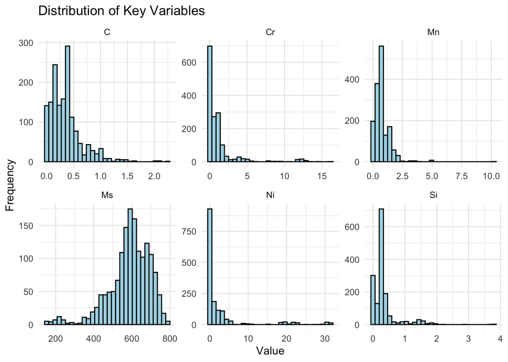

Ms is ranged between 150 to 800 degree Celsius. However, the most of the data are in 350 to 800 degree Celsius. The model may be designed for a limited range of temperature where we have more data (350 to 800C).

Carbon (C) has some zero contents which does not make any sense. Steel means Iron + Carbon. Iron without Carbon is not steel. C rows with zero content should be removed.

### Scatter plot for one element and Martensite starting temperature

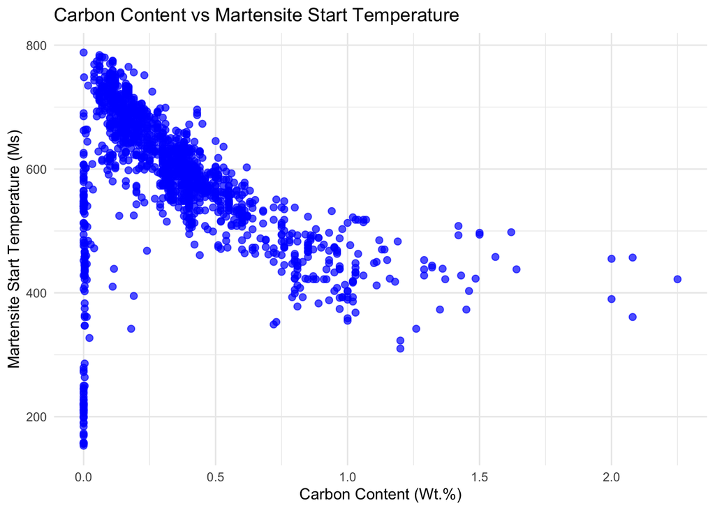

Carbon rows with zero content are recognized.

### Histogram of Martensite starting temperature

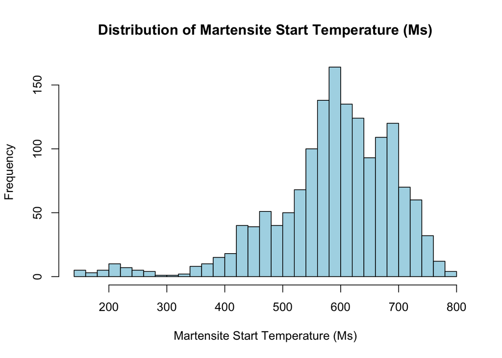

### Filtering the dataset for temperatures between 300 to 800 degree Celsius

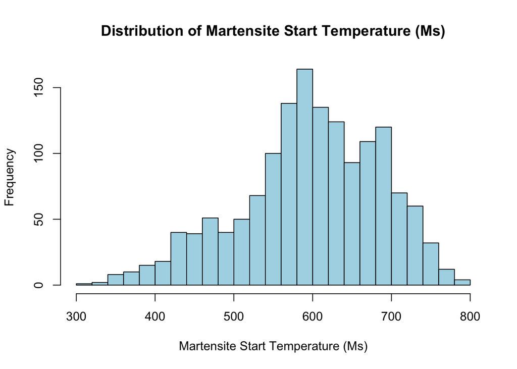

### Building GLM models

1. Previous knowledge in Materials Science has been utilized to select important predictors. I am not sure if this is a correct approach.

```
Call:
glm(formula = Ms ~ C + Ni + Mn + Mo + Si + Cr + V + Co, family = gaussian,
    data = filtered_dataset)

Coefficients:
             Estimate Std. Error t value Pr(>|t|)
(Intercept)  750.6469     3.1633 237.300  < 2e-16 ***
C           -260.1772     4.4241 -58.809  < 2e-16 ***
Ni           -12.4065     0.2859 -43.394  < 2e-16 ***
Mn           -25.5874     1.9657 -13.017  < 2e-16 ***
Mo            -7.7315     2.0623  -3.749 0.000184 ***
Si           -15.6230     2.9154  -5.359 9.69e-08 ***
Cr            -7.1898     0.5425 -13.254  < 2e-16 ***
V              8.3285     3.5131   2.371 0.017881 *
Co             2.0491     0.9144   2.241 0.025184 *
---
Signif. codes:  0 '***' 0.001 '**' 0.01 '*' 0.05 '.' 0.1 ' ' 1

(Dispersion parameter for gaussian family taken to be 1997.601)

    Null deviance: 12075332  on 1502  degrees of freedom
Residual deviance:  2984416  on 1494  degrees of freedom
AIC: 15699

Number of Fisher Scoring iterations: 2
```

At the first glance, V and Co present weak predictors. These two have to be removed.

### Checking residuals

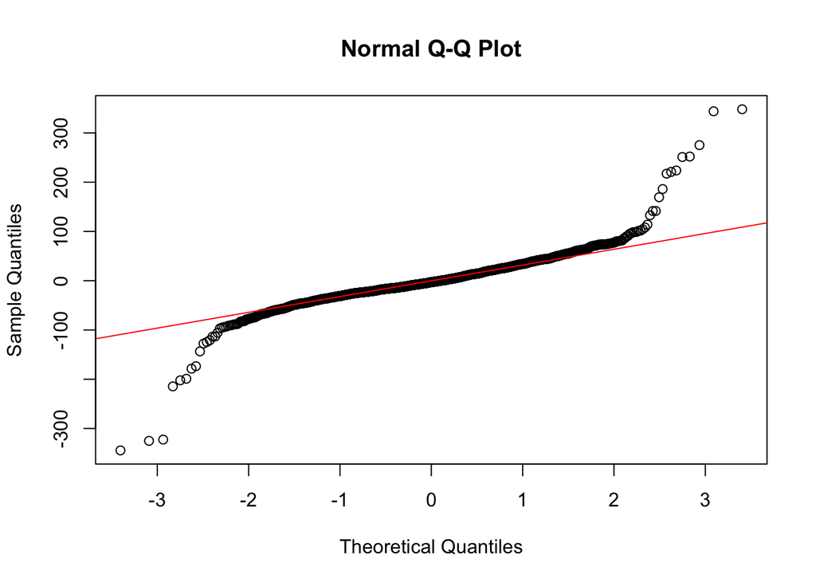

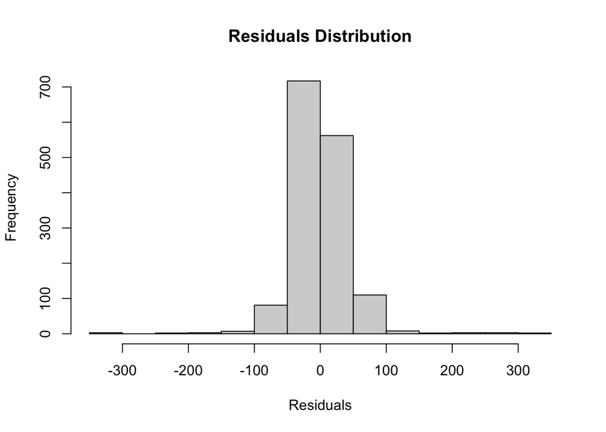

Q-Q plot shows deviations for extreme values.

### Identifying Outliers

```
         C   Mn      Si       Cr       Ni      Mo     V   Co    Al   W   Cu Nb
9    0.000 0.00 0.00000  0.53096 30.96549 0.00000 0.000 0.00 0.000 0.0 0.00  0
48   0.280 0.39 0.16000  2.35000  0.06000 0.06000 0.530 0.00 0.000 4.1 0.00  0
97   0.000 0.00 0.00000  0.00000 30.77361 1.36279 0.000 0.00 0.000 0.0 0.00  0
193  0.500 0.35 1.00000  0.11000  0.19000 0.50000 0.000 0.00 0.000 0.0 0.00  0
209  0.300 0.48 2.20000 10.50000  0.12000 1.00000 0.012 0.00 0.000 0.0 0.07  0
220  0.300 1.55 0.20000  0.00000  0.00000 0.28000 0.000 0.00 0.000 0.0 0.00  0
302  0.110 0.50 0.22000  0.00000  0.00000 0.56000 0.000 0.00 0.003 0.0 0.00  0
328  0.160 0.60 0.25000  0.20000  1.50000 0.05000 0.000 0.00 0.000 0.0 0.00  0
331  0.000 0.00 1.92824  0.00000 31.53985 0.00000 0.000 0.00 0.000 0.0 0.00  0
334  0.550 0.75 1.50000  0.70000  0.00000 0.00000 0.000 0.00 0.000 0.0 0.00  0
365  1.040 0.33 0.26000  1.53000  0.31000 0.01000 0.010 0.00 0.000 0.0 0.20  0
387  0.330 1.12 0.30000  0.11000  0.24000 0.04000 0.000 0.00 0.010 0.0 0.19  0
389  0.190 1.17 0.41000  0.06000  0.00000 0.00000 0.000 0.00 0.000 0.0 0.00  0
403  0.400 1.38 1.50000  0.00000  0.00000 0.80000 0.000 0.00 0.000 0.0 0.00  0
```

[output cut: 83 more lines]

### Remove rows where Carbon content is zero, update the model, and the summary of the model.

2. The model has been updated after removing zero cells for Carbon content.

```
Call:
glm(formula = Ms ~ C + Ni + Mn + Mo + Si + Cr + V + Co, family = gaussian,
    data = filtered_dataset_no_C0)

Coefficients:
             Estimate Std. Error t value Pr(>|t|)
(Intercept)  759.1787     3.0472 249.140  < 2e-16 ***
C           -266.4946     4.1713 -63.887  < 2e-16 ***
Ni           -14.0982     0.3195 -44.121  < 2e-16 ***
Mn           -29.0478     1.8747 -15.494  < 2e-16 ***
Mo            -8.0919     2.0278  -3.991 6.92e-05 ***
Si           -16.6972     2.7500  -6.072 1.61e-09 ***
Cr            -7.5038     0.5069 -14.804  < 2e-16 ***
V              8.3673     3.4113   2.453  0.01429 *
Co             2.3044     0.8627   2.671  0.00764 **
---
Signif. codes:  0 '***' 0.001 '**' 0.01 '*' 0.05 '.' 0.1 ' ' 1

(Dispersion parameter for gaussian family taken to be 1730.735)

    Null deviance: 11796080  on 1456  degrees of freedom
Residual deviance:  2506104  on 1448  degrees of freedom
AIC: 15010

Number of Fisher Scoring iterations: 2
```

### Updating the model by removing Mo and Co and adding an interaction parameter between Carbon and Manganese.

3. The model has been updated after removing weak predictors.

```
Call:
glm(formula = Ms ~ C * Mn + Ni + Si + Cr + V, family = gaussian,
    data = filtered_dataset_no_C0)

Coefficients:
             Estimate Std. Error t value Pr(>|t|)
(Intercept)  749.7319     3.1524 237.829  < 2e-16 ***
C           -240.0692     5.6937 -42.164  < 2e-16 ***
Mn           -18.6538     2.3738  -7.858 7.54e-15 ***
Ni           -13.7303     0.3167 -43.358  < 2e-16 ***
Si           -13.2855     2.7810  -4.777 1.96e-06 ***
Cr            -8.3034     0.5069 -16.382  < 2e-16 ***
V              1.1567     3.1278   0.370    0.712
C:Mn         -39.6809     6.0769  -6.530 9.09e-11 ***
---
Signif. codes:  0 '***' 0.001 '**' 0.01 '*' 0.05 '.' 0.1 ' ' 1

(Dispersion parameter for gaussian family taken to be 1701.745)

    Null deviance: 11796080  on 1456  degrees of freedom
Residual deviance:  2465829  on 1449  degrees of freedom
AIC: 14984

Number of Fisher Scoring iterations: 2
```

### Update the model by removing V and add an interaction parameter between Carbon and Nickel.

4. Further revision in the model by removing a weak parameter and adding a new interaction parameter

```
Call:
glm(formula = Ms ~ C * Mn + C * Ni + Si + Cr, family = gaussian,
    data = filtered_dataset_no_C0)

Coefficients:
             Estimate Std. Error t value Pr(>|t|)
(Intercept)  751.5794     3.0913 243.129  < 2e-16 ***
C           -231.2782     5.4214 -42.660  < 2e-16 ***
Mn           -19.0683     2.3316  -8.178 6.23e-16 ***
Ni           -13.0691     0.3241 -40.326  < 2e-16 ***
Si           -15.1211     2.7398  -5.519 4.03e-08 ***
Cr            -8.5661     0.4913 -17.436  < 2e-16 ***
C:Mn         -41.8580     5.8686  -7.133 1.55e-12 ***
C:Ni         -13.8302     1.9610  -7.053 2.71e-12 ***
---
Signif. codes:  0 '***' 0.001 '**' 0.01 '*' 0.05 '.' 0.1 ' ' 1

(Dispersion parameter for gaussian family taken to be 1645.423)

    Null deviance: 11796080  on 1456  degrees of freedom
Residual deviance:  2384218  on 1449  degrees of freedom
AIC: 14935

Number of Fisher Scoring iterations: 2
```

### Log Model

After reviewing Q-Q plot and its deviations in extreme values and a skewed residual distribution, a log model has been considered. It will be compared with the first model at the end.

```
Call:
glm(formula = log(Ms) ~ C * Mn + C * Ni + Si + Cr, family = gaussian,
    data = filtered_dataset_no_C0)

Coefficients:
              Estimate Std. Error  t value Pr(>|t|)
(Intercept)  6.6617940  0.0053830 1237.558  < 2e-16 ***
C           -0.4182892  0.0094406  -44.307  < 2e-16 ***
Mn          -0.0407894  0.0040602  -10.046  < 2e-16 ***
Ni          -0.0240965  0.0005644  -42.697  < 2e-16 ***
Si          -0.0245566  0.0047709   -5.147 3.01e-07 ***
Cr          -0.0152132  0.0008555  -17.783  < 2e-16 ***
C:Mn        -0.0698957  0.0102193   -6.840 1.17e-11 ***
C:Ni        -0.0248897  0.0034148   -7.289 5.12e-13 ***
---
Signif. codes:  0 '***' 0.001 '**' 0.01 '*' 0.05 '.' 0.1 ' ' 1

(Dispersion parameter for gaussian family taken to be 0.004989449)

    Null deviance: 37.6380  on 1456  degrees of freedom
Residual deviance:  7.2297  on 1449  degrees of freedom
AIC: -3578

Number of Fisher Scoring iterations: 2
```

### Performing ANOVA for the updated model.

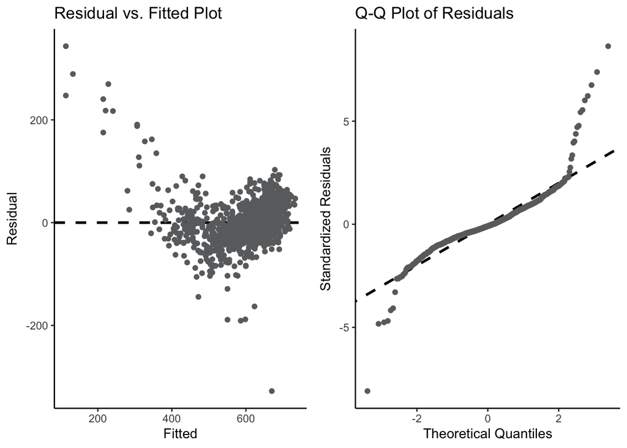

### Performing ANOVA for the Log Model

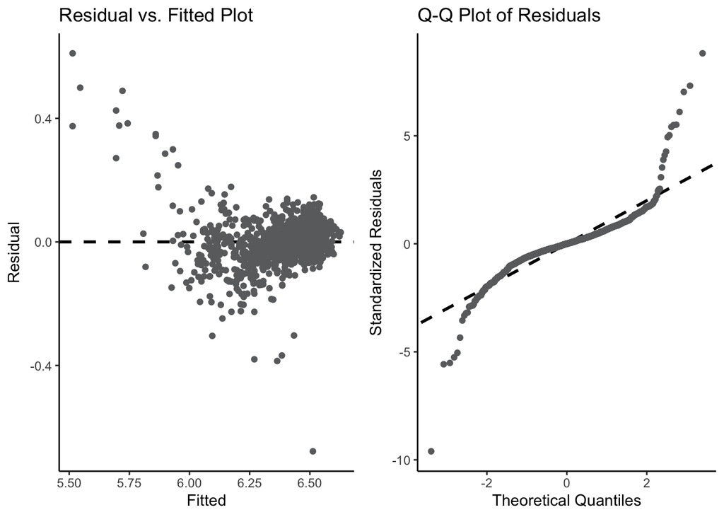

### Checking leverage and influential points for both models

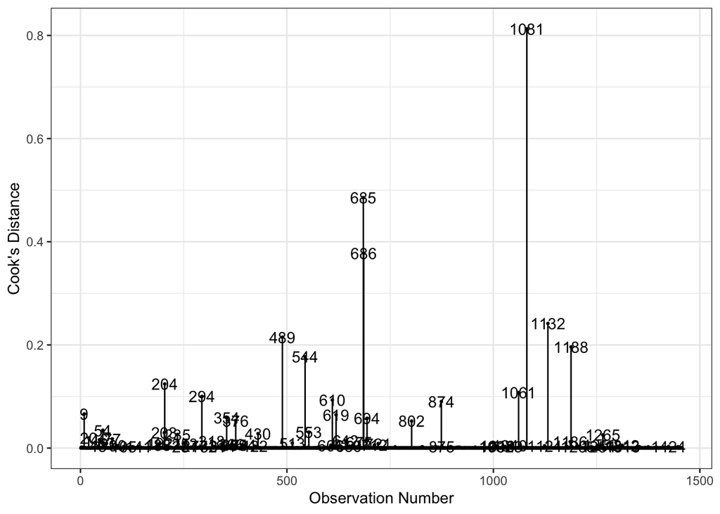

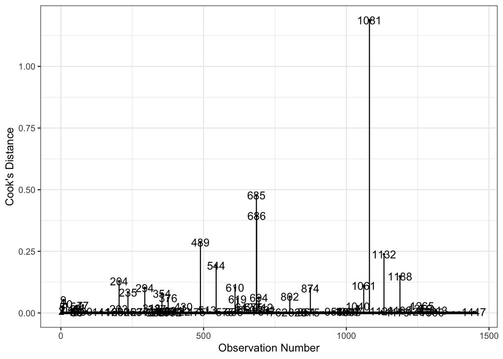

### Investigate the Influential Points

```
         C    Mn   Si    Cr   Ni   Mo    V Co Al W   Cu Nb Ti B     N     Ms
1145 0.022 10.24 0.00  8.19 0.00 0.00 0.00  0  0 0 0.00  0  0 0 0.206 327.15
718  2.250  0.00 0.00 11.50 0.00 0.80 0.20  0  0 0 0.00  0  0 0 0.000 422.00
719  2.080  0.39 0.28 11.48 0.31 0.02 0.04  0  0 0 0.15  0  0 0 0.000 457.00
```

By reviewing Carbon and Chromium contents, it can be decided that these three points are not representing routine chemistry for steels. They are unusual, and they can be removed.

### Remove Influential Points and Updating Models

```
Call:
glm(formula = Ms ~ C * Mn + C * Ni + Si + Cr, family = gaussian,
    data = filtered_dataset_no_influential)

Coefficients:
             Estimate Std. Error t value Pr(>|t|)
(Intercept)  753.7295     3.2150 234.445  < 2e-16 ***
C           -242.2463     5.5389 -43.735  < 2e-16 ***
Mn           -16.9666     2.6015  -6.522 9.58e-11 ***
Ni           -13.2149     0.3142 -42.053  < 2e-16 ***
Si           -15.0063     2.5997  -5.772 9.55e-09 ***
Cr            -9.1535     0.4711 -19.429  < 2e-16 ***
C:Mn         -40.5155     5.9696  -6.787 1.67e-11 ***
C:Ni         -12.4910     1.8647  -6.699 3.01e-11 ***
---
Signif. codes:  0 '***' 0.001 '**' 0.01 '*' 0.05 '.' 0.1 ' ' 1

(Dispersion parameter for gaussian family taken to be 1481.353)

    Null deviance: 11670630  on 1453  degrees of freedom
Residual deviance:  2142037  on 1446  degrees of freedom
AIC: 14751

Number of Fisher Scoring iterations: 2
```

```
Call:
glm(formula = log(Ms) ~ C * Mn + C * Ni + Si + Cr, family = gaussian,
    data = filtered_dataset_no_influential)

Coefficients:
              Estimate Std. Error  t value Pr(>|t|)
(Intercept)  6.6636794  0.0055789 1194.433  < 2e-16 ***
C           -0.4350978  0.0096117  -45.267  < 2e-16 ***
Mn          -0.0349821  0.0045145   -7.749 1.74e-14 ***
Ni          -0.0242615  0.0005453  -44.491  < 2e-16 ***
Si          -0.0243802  0.0045113   -5.404 7.60e-08 ***
Cr          -0.0161918  0.0008175  -19.806  < 2e-16 ***
C:Mn        -0.0707458  0.0103590   -6.829 1.25e-11 ***
C:Ni        -0.0225066  0.0032359   -6.955 5.31e-12 ***
---
Signif. codes:  0 '***' 0.001 '**' 0.01 '*' 0.05 '.' 0.1 ' ' 1

(Dispersion parameter for gaussian family taken to be 0.004460798)

    Null deviance: 37.1057  on 1453  degrees of freedom
Residual deviance:  6.4503  on 1446  degrees of freedom
AIC: -3733.4

Number of Fisher Scoring iterations: 2
```

### Investigate Points Found Out by Cook’s Distances

```
        C   Mn   Si    Cr   Ni   Mo    V Co Al    W   Cu Nb Ti B N  Ms
1199 1.36 1.84 1.14  0.15 1.81 1.41 0.00  0  0 0.00 0.00  0  0 0 0 439
1259 2.08 0.39 0.28 11.48 0.31 0.02 0.04  0  0 0.00 0.15  0  0 0 0 361
1122 1.56 0.37 0.20 12.46 0.26 0.54 0.65  0  0 0.28 0.10  0  0 0 0 458
```

These observation are valid and will be kept in the dataset.

### Apply the Residuals Check to the Filtered Dataset

### Counting Outliers

```
        outlier    n
1 Not Suspected 1429
2     Suspected   25
```

### Plotting Carbon Content with Martensite Starting Temperature

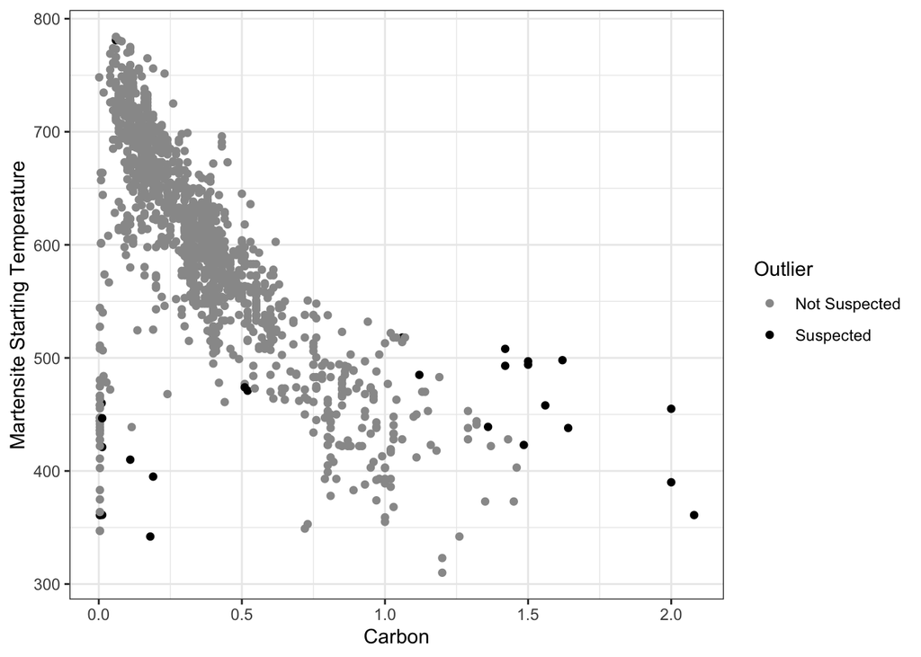

### Performing ANOVA for Both Models After Removing Influential Points

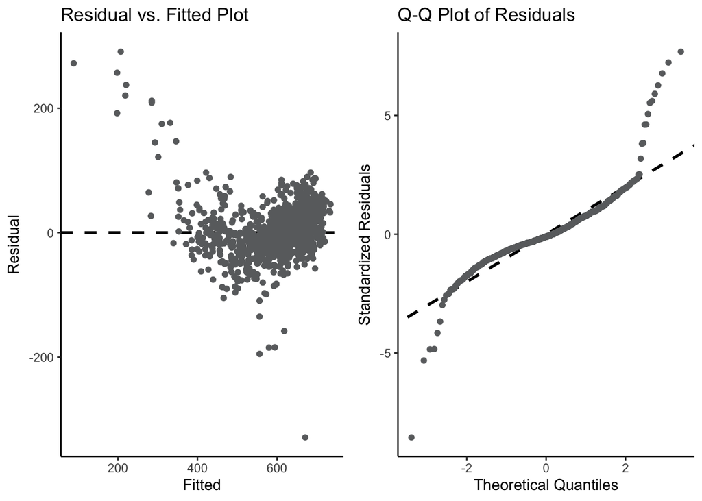

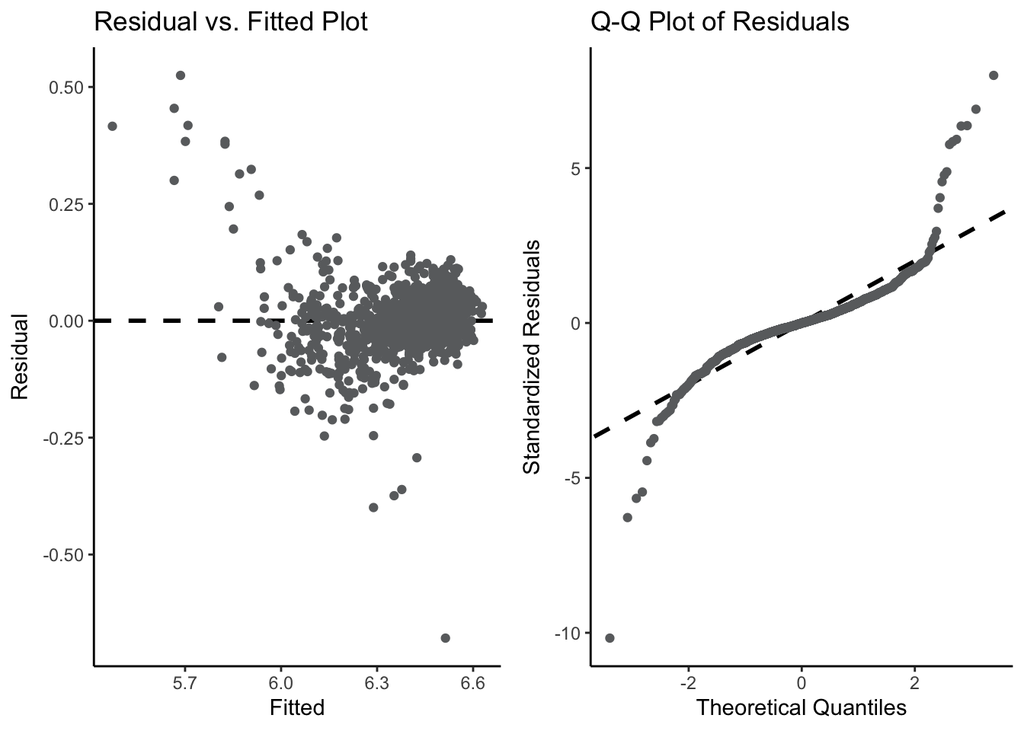

### Check Multicollinearity

#### First Model

```
       C       Mn       Ni       Si       Cr     C:Mn     C:Ni
2.392626 2.309298 1.417059 1.067519 1.073750 2.869351 1.194094
```

#### Log Model

```
       C       Mn       Ni       Si       Cr     C:Mn     C:Ni
2.392626 2.309298 1.417059 1.067519 1.073750 2.869351 1.194094
```

There is no concerning level of multicollinearity for both models.

### Remove Identified Outliers and Revise Both Models

```
Call:
glm(formula = Ms ~ C * Mn + C * Ni + Si + Cr, family = gaussian,
    data = filtered_dataset_no_influential_no_outlier)

Coefficients:
             Estimate Std. Error t value Pr(>|t|)
(Intercept)  769.4121     2.6216 293.489  < 2e-16 ***
C           -286.7145     4.5296 -63.299  < 2e-16 ***
Mn           -16.4197     2.1971  -7.473 1.36e-13 ***
Ni           -14.0369     0.2361 -59.454  < 2e-16 ***
Si           -13.8905     1.8663  -7.443 1.70e-13 ***
Cr           -10.1289     0.3825 -26.478  < 2e-16 ***
C:Mn         -41.4509     4.7323  -8.759  < 2e-16 ***
C:Ni          -8.3589     1.3578  -6.156 9.68e-10 ***
---
Signif. codes:  0 '***' 0.001 '**' 0.01 '*' 0.05 '.' 0.1 ' ' 1

(Dispersion parameter for gaussian family taken to be 760.2129)

    Null deviance: 10969684  on 1428  degrees of freedom
Residual deviance:  1080263  on 1421  degrees of freedom
AIC: 13545

Number of Fisher Scoring iterations: 2
```

### Performing ANOVA for the First Model After Removing Outliers

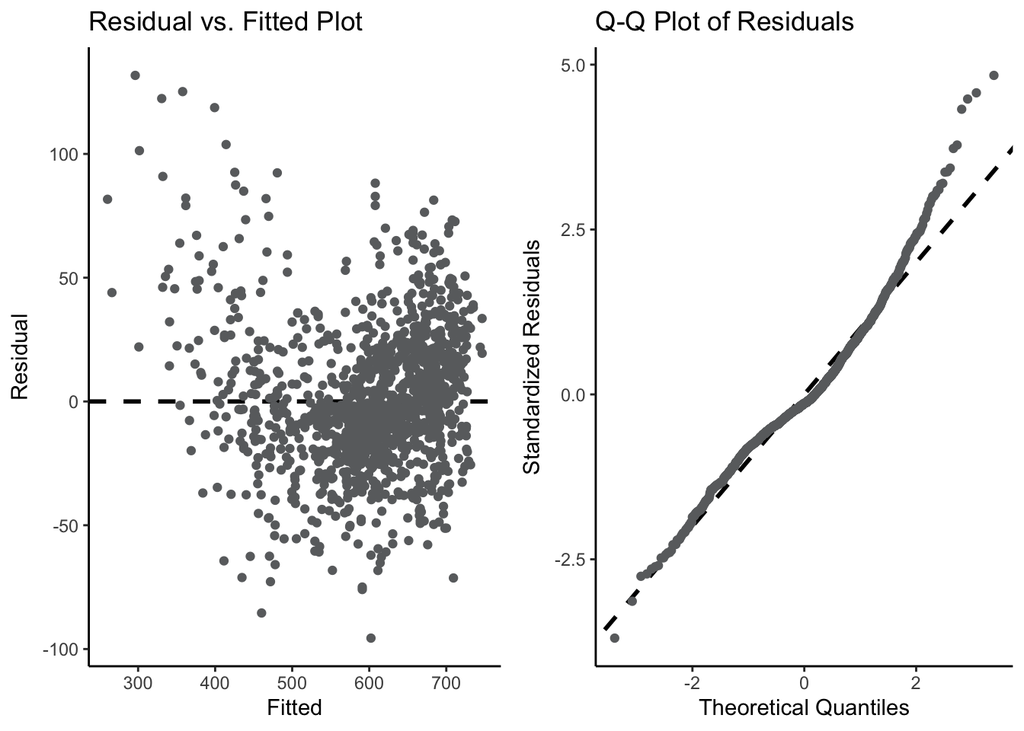

### Checking Cook’s Distance After Removing Outliers

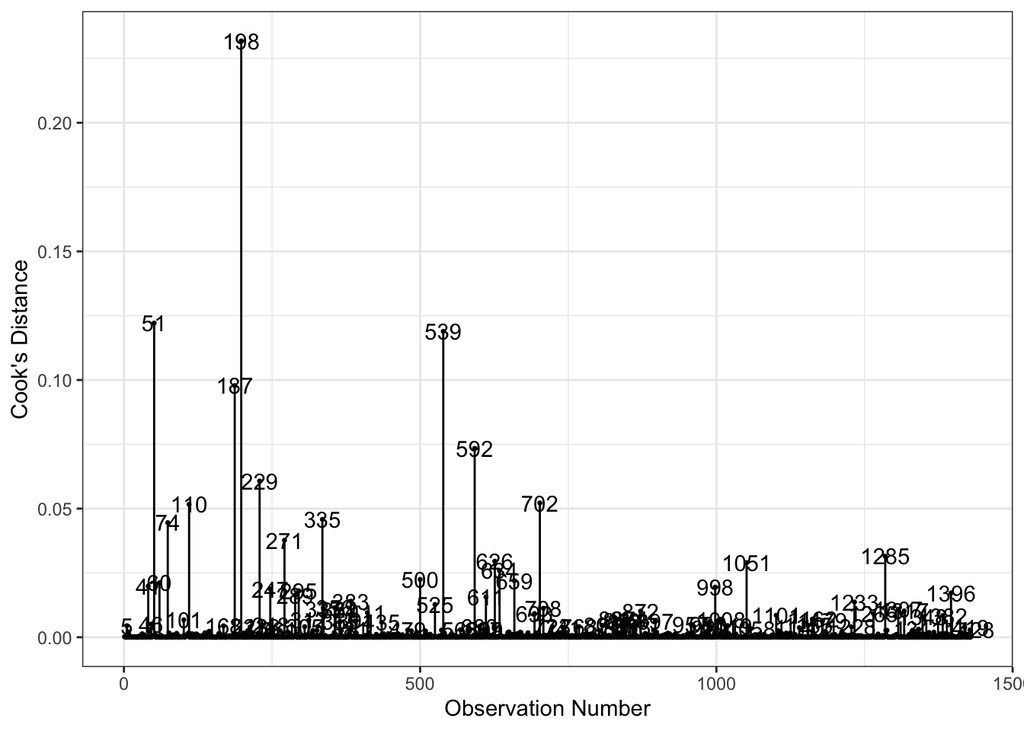

### Log Model After Removing Outliers

```
Call:
glm(formula = log(Ms) ~ C * Mn + C * Ni + Si + Cr, family = gaussian,
    data = filtered_dataset_no_influential_no_outlier)

Coefficients:
              Estimate Std. Error  t value Pr(>|t|)
(Intercept)  6.6889963  0.0043407 1540.990  < 2e-16 ***
C           -0.5102408  0.0074998  -68.034  < 2e-16 ***
Mn          -0.0319981  0.0036379   -8.796  < 2e-16 ***
Ni          -0.0255305  0.0003909  -65.309  < 2e-16 ***
Si          -0.0225859  0.0030902   -7.309 4.48e-13 ***
Cr          -0.0175028  0.0006334  -27.633  < 2e-16 ***
C:Mn        -0.0751043  0.0078355   -9.585  < 2e-16 ***
C:Ni        -0.0154270  0.0022482   -6.862 1.01e-11 ***
---
Signif. codes:  0 '***' 0.001 '**' 0.01 '*' 0.05 '.' 0.1 ' ' 1

(Dispersion parameter for gaussian family taken to be 0.002084123)

    Null deviance: 34.4909  on 1428  degrees of freedom
Residual deviance:  2.9615  on 1421  degrees of freedom
AIC: -4756.5

Number of Fisher Scoring iterations: 2
```

### Performing ANOVA for The Log Model After Removing Outliers

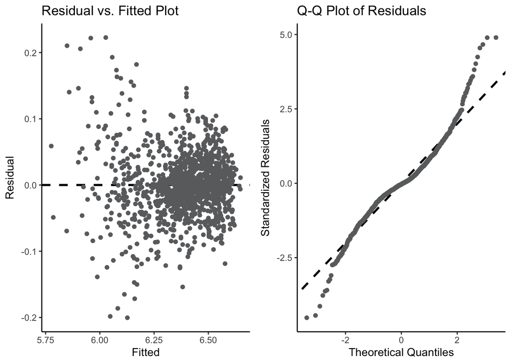

### Checking Cook’s Distance

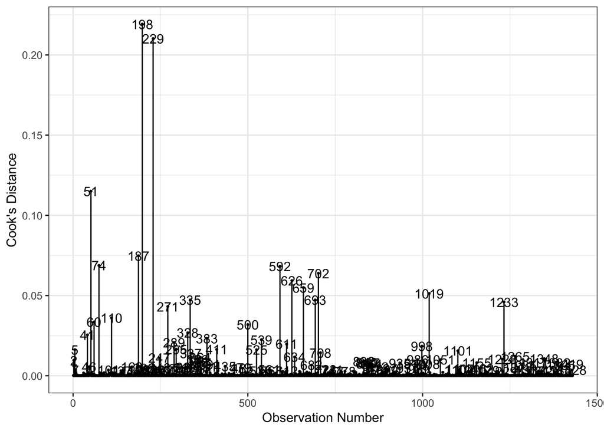

### Table 1

|  | Ms | C | Mn | Ni | Si | Cr |
| --- | --- | --- | --- | --- | --- | --- |
|  | Min. :310.0 | Min. :0.0016 | Min. :0.0000 | Min. : 0.000 | Min. :0.0000 | Min. : 0.000 |
|  | 1st Qu.:553.5 | 1st Qu.:0.1600 | 1st Qu.:0.4700 | 1st Qu.: 0.000 | 1st Qu.:0.2000 | 1st Qu.: 0.000 |
|  | Median :605.0 | Median :0.3300 | Median :0.6900 | Median : 0.150 | Median :0.2600 | Median : 0.520 |
|  | Mean :601.8 | Mean :0.3617 | Mean :0.7917 | Mean : 1.558 | Mean :0.3475 | Mean : 1.043 |
|  | 3rd Qu.:670.0 | 3rd Qu.:0.4400 | 3rd Qu.:0.9700 | 3rd Qu.: 1.580 | 3rd Qu.:0.3400 | 3rd Qu.: 1.150 |
|  | Max. :784.0 | Max. :1.4600 | Max. :4.9500 | Max. :27.200 | Max. :3.8000 | Max. :16.200 |

### Updated Summary for the Revised Dataset

```
       Ms              C                Mn               Ni
 Min.   :310.0   Min.   :0.0016   Min.   :0.0000   Min.   : 0.000
 1st Qu.:553.5   1st Qu.:0.1600   1st Qu.:0.4700   1st Qu.: 0.000
 Median :605.0   Median :0.3300   Median :0.6900   Median : 0.150
 Mean   :601.8   Mean   :0.3617   Mean   :0.7917   Mean   : 1.558
 3rd Qu.:670.0   3rd Qu.:0.4400   3rd Qu.:0.9700   3rd Qu.: 1.580
 Max.   :784.0   Max.   :1.4600   Max.   :4.9500   Max.   :27.200
       Si               Cr
 Min.   :0.0000   Min.   : 0.000
 1st Qu.:0.2000   1st Qu.: 0.000
 Median :0.2600   Median : 0.520
 Mean   :0.3475   Mean   : 1.043
 3rd Qu.:0.3400   3rd Qu.: 1.150
 Max.   :3.8000   Max.   :16.200
```

```
   vars    n   mean    sd median trimmed   mad min    max  range  skew kurtosis
Ms    1 1429 601.77 87.65 605.00  606.84 85.99 310 784.00 474.00 -0.49    -0.07
C     2 1429   0.36  0.26   0.33    0.33  0.22   0   1.46   1.46  1.27     1.79
Mn    3 1429   0.79  0.56   0.69    0.74  0.34   0   4.95   4.95  2.15    10.15
Ni    4 1429   1.56  3.82   0.15    0.70  0.22   0  27.20  27.20  4.37    20.23
Si    5 1429   0.35  0.40   0.26    0.26  0.10   0   3.80   3.80  3.26    15.13
Cr    6 1429   1.04  1.99   0.52    0.60  0.77   0  16.20  16.20  4.18    20.19
     se
Ms 2.32
C  0.01
Mn 0.01
Ni 0.10
Si 0.01
Cr 0.05
```

### Histograms for Key Variables in the Revised Dataset

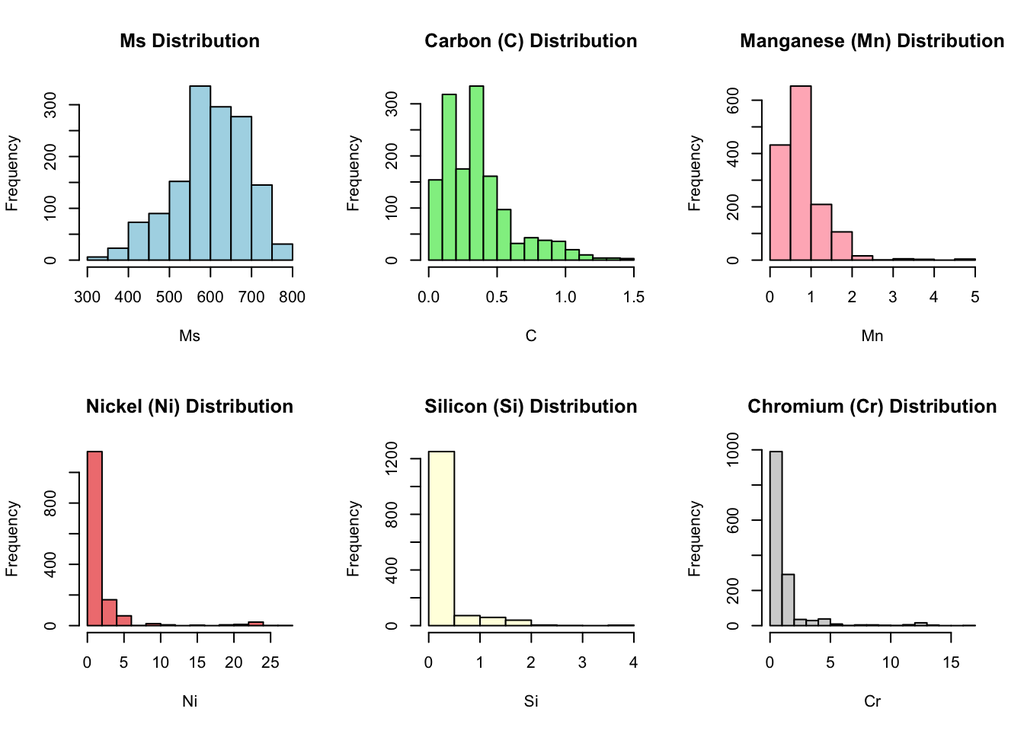

### Table 2 Untransformed Model

[output not shown]

#### The model is:

$Ms = 769.41 -286.71 C -16.42 Mn -14.04 Ni - 13.89 Si - 10.13Cr -41.45C:Mn - 8.36 C:Ni$

### Table 2 Log-Transformed Model

[output not shown]

### Cross-Validation

#### 5-Fold

### Cross-Validation for the First Model

#### 5-Fold

```
[1] 774.1075 772.0337
```

#### 10-Fold

```
[1] 779.8235 778.5136
```

### Interpretation

1. **Consistency**: Both 5-fold and 10-fold cross-validations yield fairly similar results, which indicates stability in the model’s predictive performance across different validation approaches.
2. **Slight Increase with 10-fold**: The error slightly increased with 10-fold cross-validation. This could be due to the smaller subsets in each fold, as 10-fold divides the data into smaller groups compared to 5-fold, potentially revealing more variability or minor overfitting effects.
3. **Implications for Model Evaluation**: These results suggest that while the untransformed model’s performance is stable, there is no significant improvement in prediction error when using more folds. However, if computational efficiency or consistency is a priority, 5-fold might be a suitable choice.

### Cross-Validation for the Second Model (Log Model)

#### 5-Fold

```
[1] 0.002146943 0.002138416
```

#### 10-Fold

```
[1] 0.002144025 0.002140193
```

### The **Leave-One-Out Cross-Validation (LOOCV)**

#### The Untransformed Model

```
[1] 772.7368 772.7308
```

#### The Log-Transformed Model

```
[1] 0.002125407 0.002125388
```